Van*Lifers*

Steve English · Product development portfolio

# Future product range opportunities.

This portfolio brings together a selection of products and product ranges I have been developing for the campervan, motorhome and wider leisure vehicle markets.

Many of these projects have already progressed through extensive design and engineering development, with engineering reports, materials and component specifications, supplier availability, sourcing links and prototype costings completed and organised in preparation for prototype manufacture. Others are approaching that stage.

Each has been developed with practical applications, commercial viability and potential market demand in mind. Together, they offer opportunities to broaden the VanLifers range beyond its existing connectivity products.

Campervans & motorhomesProduct engineering & developmentPotential VanLifers range expansion

Explore the portfolio

## Five product families. One wider vision.

Select a product to explore its purpose, key benefits and potential place within a broader VanLifers offering.

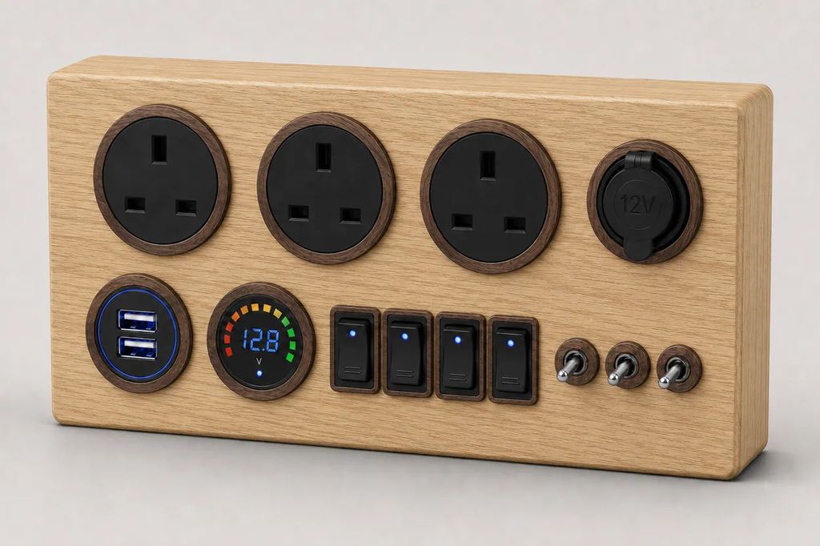

Interior electrical & finishing systems

### Electrasthetics™

A cohesive family of modular housings, sockets, switches, lighting and smart-control accessories designed to make campervan electrics look as considered as the rest of the interior.

[figure not shown]

Powered solar mounting

### SolarRaise™ OneTouch

An adjustable roof-mounted solar platform designed to help campervan and motorhome owners improve panel orientation and make better use of available sunlight.

[figure not shown]

Starlink Mini positioning

### StarRise

A powered directional roof-mounting solution developed specifically around Starlink Mini, giving users a convenient way to position their equipment without repeatedly climbing onto the roof.

[figure not shown]

Underslung split air conditioning

### ExoSplit ArmourPod™

A protected underbody split air-conditioning concept for 12V and 24V campervan systems, designed to free the roof for solar and avoid bulky interior or rooftop equipment.

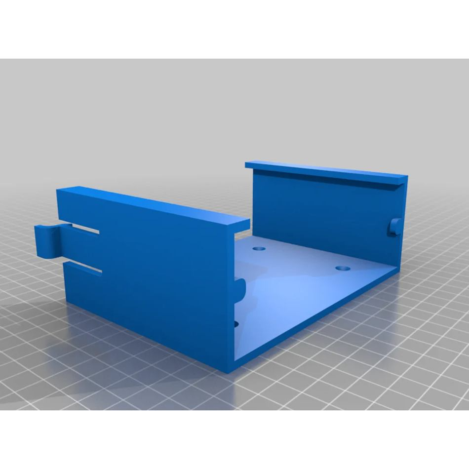

Fitting, mounting & installation accessories

### VanLifers Adapt™

A developing family of purpose-designed adaptors, spacers, housings and mounting accessories that help make installations cleaner, simpler and more professional.

Illustrations communicate product direction and may differ from final manufactured configurations. Technical documentation and detailed prototype costings are held separately.

Interior electrical & finishing systems

# Electrasthetics™

One coordinated look. A whole world of possibilities.

A cohesive family of modular housings, sockets, switches, lighting and smart-control accessories designed to make campervan electrics look as considered as the rest of the interior.

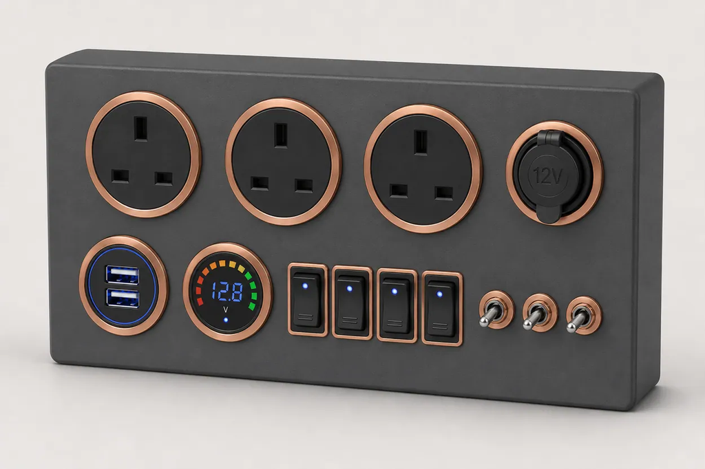

The idea

## Electrical installations should look like part of the furniture—not an afterthought.

A cohesive family of modular housings, sockets, switches, lighting and smart-control accessories designed to make campervan electrics look as considered as the rest of the interior.

**Range opportunity**

A scalable design language spanning everyday essentials through to premium interior upgrades.

[Explore existing Electrasthetics presentation ↗](https://britishlionsroar.github.io/Electrasthetics_Index.html)

Customer-facing highlights

## What makes it interesting

- Coordinated styling across multiple accessory families
- 12V / 24V electrical accessories and complementary mains fittings
- Switches, sockets, charging points and control-panel housings
- Lighting, heater-control and smart-accessory options
- Finishes and formats to suit different interiors

## Explore the Electrasthetics range

A selection of the coordinated product visuals, finishes and accessory families developed for the range.

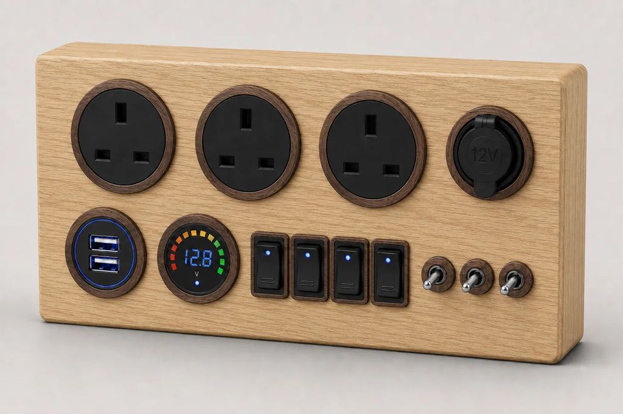

Coordinated oak electrical control panel

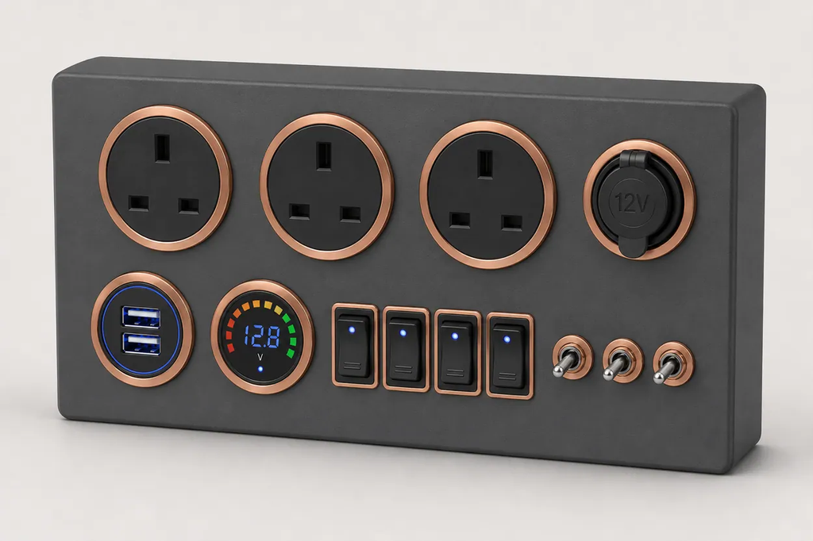

Graphite and copper modular control panel

[figure not shown]

Multi-module graphite control housings

[figure not shown]

Oak compact modular accessory housings

[figure not shown]

Pale blue coordinated accessory housings

[figure not shown]

Individual oak accessory modules

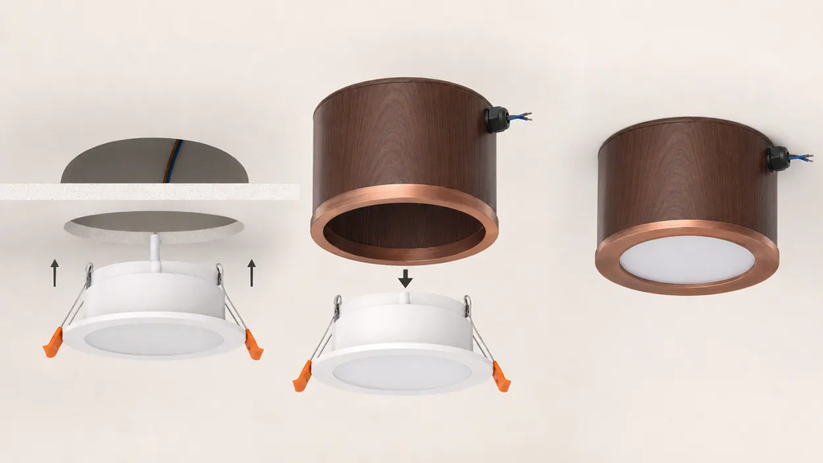

Wood and copper downlight housing

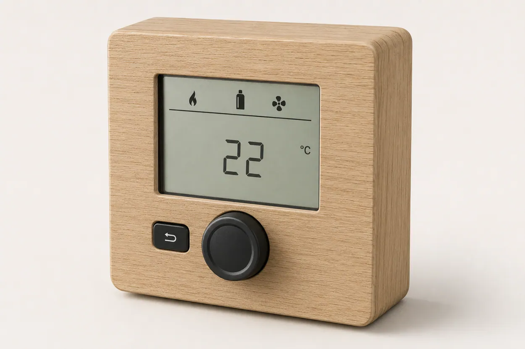

Oak thermostat housing

[figure not shown]

Oak router enclosure

[figure not shown]

Wood-effect flexible cable trunking

[figure not shown]

Decorative cable trunking finishes

[figure not shown]

Decorative corner trunking sections

Powered solar mounting

# SolarRaise™ OneTouch

Make more of the sun, without giving up your roof.

An adjustable roof-mounted solar platform designed to help campervan and motorhome owners improve panel orientation and make better use of available sunlight.

[figure not shown]

The idea

## Flat-mounted solar is convenient. Adjustable solar opens up more possibilities.

An adjustable roof-mounted solar platform designed to help campervan and motorhome owners improve panel orientation and make better use of available sunlight.

**Range opportunity**

A distinctive solar upgrade for off-grid customers who value energy independence and roof-space efficiency.

Customer-facing highlights

## What makes it interesting

- Powered panel positioning
- Seasonal and operating presets
- Designed around campervan and motorhome roof installations
- Practical consideration of stowed travel position and wind exposure
- Potential compatibility with different solar panel arrangements

Starlink Mini positioning

# StarRise

Better positioning for connectivity on the move.

A powered directional roof-mounting solution developed specifically around Starlink Mini, giving users a convenient way to position their equipment without repeatedly climbing onto the roof.

[figure not shown]

The idea

## Starlink Mini is compact. Its mounting can be smarter.

A powered directional roof-mounting solution developed specifically around Starlink Mini, giving users a convenient way to position their equipment without repeatedly climbing onto the roof.

**Range opportunity**

A natural adjacent product to the existing VanLifers communications range.

Customer-facing highlights

## What makes it interesting

- Designed specifically for Starlink Mini
- Powered directional positioning
- Roof-based installation concept
- Convenient operation from the vehicle
- Complements the VanLifers connectivity offering

[figure not shown]

Underslung split air conditioning

# ExoSplit ArmourPod™

Cool the van. Keep the roof.

A protected underbody split air-conditioning concept for 12V and 24V campervan systems, designed to free the roof for solar and avoid bulky interior or rooftop equipment.

[figure not shown]

The idea

## Climate control should not mean sacrificing the best space on the vehicle.

A protected underbody split air-conditioning concept for 12V and 24V campervan systems, designed to free the roof for solar and avoid bulky interior or rooftop equipment.

**Range opportunity**

A premium climate-control proposition with clear relevance to professional converters and self-build owners.

Customer-facing highlights

## What makes it interesting

- 12V / 24V product direction
- Underbody compressor and condenser arrangement
- Protected, serviceable enclosure concept
- Slim interior evaporator / blower options
- Designed around off-grid use and retaining rooftop solar capacity

Fitting, mounting & installation accessories

# VanLifers Adapt™

The small parts that solve the awkward problems.

A developing family of purpose-designed adaptors, spacers, housings and mounting accessories that help make installations cleaner, simpler and more professional.

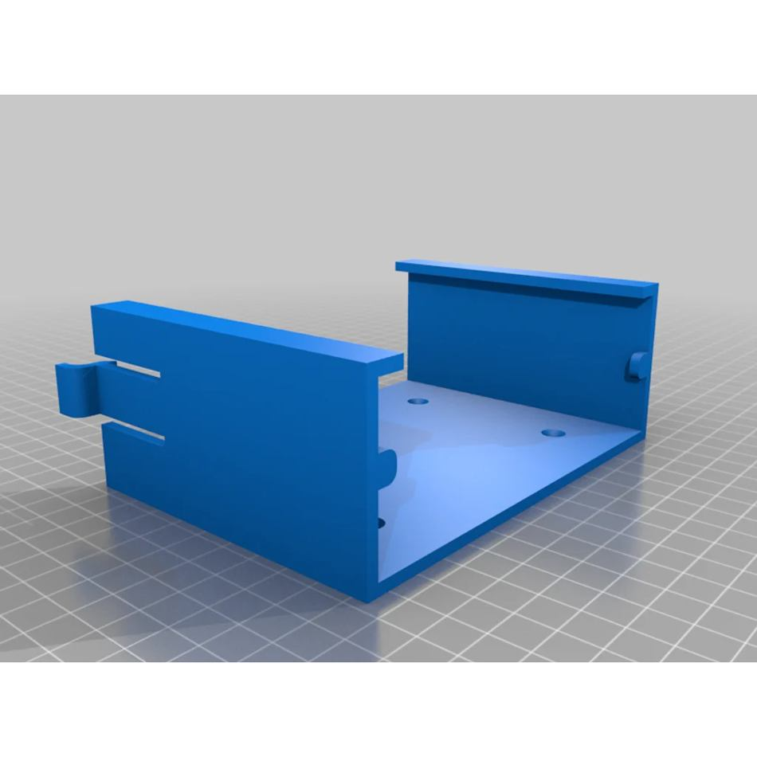

The idea

## Every conversion has those awkward little fitting problems. This range is about solving them properly.

A developing family of purpose-designed adaptors, spacers, housings and mounting accessories that help make installations cleaner, simpler and more professional.

**Range opportunity**

A practical accessories range that could grow alongside every other VanLifers product family.

Customer-facing highlights

## What makes it interesting

- Purpose-made installation adaptors and spacers
- Mounting and finishing accessories
- Solutions for varied vehicle interiors
- Designed for converters and practical DIY installations
- Potential for a broad catalogue of complementary parts

[figure not shown]